# Easy Test Solution - Liminal Package

## Introduction

This R Markdown file demonstrates the **Easy Test** solution for interactive visualization using the **Liminal** package. We will use a t-SNE embedding and a linked grand tour to explore the **fake_trees** dataset.

## Step 1: Load Packages

Install and load the necessary packages.

```r
# Install packages if not already installed
if (!require("liminal")) install.packages("liminal")
if (!require("Rtsne")) install.packages("Rtsne")
```

```r
if (!require("ggplot2")) install.packages("ggplot2")
if (!require("dplyr")) install.packages("dplyr")
# Load libraries
library(liminal)
library(Rtsne)
library(ggplot2)
library(dplyr)
```

## Step 2: Load and Prepare Data

We use the **fake_trees** dataset available in the Liminal package.

```r
data("fake_trees")
head(fake_trees)
```

|  | dim1 | dim2 | dim3 | dim4 | dim5 | dim6 | dim7 | dim8 | dim9 | dim10 | dim11 | dim12 | dim13 | dim14 | dim15 | dim16 | dim17 | dim18 | dim19 | dim20 | dim21 | dim22 | dim23 | dim24 | dim25 | dim26 | dim27 | dim28 | dim29 | … |
| --- | --- | --- | --- | --- | --- | --- | --- | --- | --- | --- | --- | --- | --- | --- | --- | --- | --- | --- | --- | --- | --- | --- | --- | --- | --- | --- | --- | --- | --- | --- |
| 1 | -6.3186042 | 1.913215 | -0.9079466 | -2.80074194 | -0.1578351 | -2.3726781 | -5.4554570 | -4.948721 | 3.345947 | 1.600703 | 0.2792004 | -0.3243474 | -4.302997 | -1.8572238 | 5.3491939 | -6.6291864 | 5.145802 | 3.107181 | 7.318003 | 5.682272 | -1.572943 | -7.420793 | -3.81139668 | -3.475493 | 4.863042 | -2.8707765 | 2.444871 | 3.024272 | -3.3577504 | … |
| 2 | -2.9833932 | 5.312838 | -5.2765917 | -2.69090033 | -0.2092053 | 5.3991111 | 6.0732723 | -2.894902 | 7.900990 | 4.642521 | 3.0663882 | -5.7332423 | 1.103480 | 2.5096166 | 2.7314688 | -5.9686639 | -1.100056 | -5.331876 | 1.876523 | 2.778761 | -1.305164 | -3.420770 | -0.88452732 | 1.830427 | 3.203462 | 0.6201456 | 4.609487 | 3.837807 | -7.2096707 | … |
| 3 | 1.7544339 | 3.699547 | 4.1095057 | -2.30241239 | -4.3522832 | 1.2661616 | 2.1710735 | -1.086526 | 3.297336 | -1.837682 | 1.8765418 | 4.5628857 | 6.738928 | 0.6612332 | -0.5089688 | -4.6070894 | 1.880105 | 2.906507 | -4.576550 | 5.942235 | 2.069874 | -3.868892 | 1.56890004 | 3.679056 | -3.658527 | 0.9860271 | -4.128756 | 1.070587 | 4.3875034 | … |
| 4 | -0.4983428 | 4.168232 | -1.6196486 | 0.07108289 | 7.4028651 | -0.7941823 | -0.7244374 | 1.687827 | -6.639766 | -0.652020 | 3.6838190 | 5.9622366 | 3.693184 | -5.0902058 | -2.8283188 | 0.3470759 | -3.233118 | 1.812361 | 1.862445 | 3.765705 | -6.358180 | 4.614512 | -0.03344118 | -2.072922 | 2.851788 | 4.7267990 | 3.228922 | 1.985609 | 0.3827461 | … |
| 5 | 2.0206307 | -4.264501 | -0.8456673 | -2.29783386 | 5.7076420 | 1.3590657 | 4.0943664 | -2.620429 | -4.319170 | 5.527092 | -5.6011434 | -6.2597848 | -3.806999 | -7.6749579 | -2.6159122 | 2.2577697 | 3.553763 | 2.293608 | -2.390277 | -8.309280 | -3.484739 | -3.662843 | -2.11602424 | -1.816169 | 1.484050 | -0.1442902 | 1.939385 | 4.910533 | 1.1192996 | … |
| 6 | 1.8911780 | -2.362171 | -7.3961502 | -0.77281937 | 2.0868666 | 5.4408354 | 7.2708912 | 2.406982 | -3.309744 | -4.718508 | 4.6490665 | -0.8576132 | 2.727012 | -2.2218501 | -1.6948315 | 3.1458064 | 2.791120 | 5.568945 | 3.659134 | -6.697032 | 4.274323 | -3.604994 | -5.62413922 | 1.304295 | 7.949347 | 8.0420288 | 5.137744 | 1.367831 | 5.2869382 | … |

## Step 3: Compute PCA

To obtain columns PC1 to PC10, we perform Principal Component Analysis (PCA) on the dataset.

```r
pcs <- prcomp(select(fake_trees, starts_with("dim")), scale. = TRUE)
pcs_df <- as.data.frame(pcs$x)
colnames(pcs_df) <- paste0("PC", 1:ncol(pcs_df))

# Merge PCA results with original dataset
fake_trees <- cbind(fake_trees, pcs_df)
head(fake_trees)
```

|  | dim1 | dim2 | dim3 | dim4 | dim5 | dim6 | dim7 | dim8 | dim9 | dim10 | dim11 | dim12 | dim13 | dim14 | dim15 | dim16 | dim17 | dim18 | dim19 | dim20 | dim21 | dim22 | dim23 | dim24 | dim25 | dim26 | dim27 | dim28 | dim29 | … |
| --- | --- | --- | --- | --- | --- | --- | --- | --- | --- | --- | --- | --- | --- | --- | --- | --- | --- | --- | --- | --- | --- | --- | --- | --- | --- | --- | --- | --- | --- | --- |
| 1 | -6.3186042 | 1.913215 | -0.9079466 | -2.80074194 | -0.1578351 | -2.3726781 | -5.4554570 | -4.948721 | 3.345947 | 1.600703 | 0.2792004 | -0.3243474 | -4.302997 | -1.8572238 | 5.3491939 | -6.6291864 | 5.145802 | 3.107181 | 7.318003 | 5.682272 | -1.572943 | -7.420793 | -3.81139668 | -3.475493 | 4.863042 | -2.8707765 | 2.444871 | 3.024272 | -3.3577504 | … |
| 2 | -2.9833932 | 5.312838 | -5.2765917 | -2.69090033 | -0.2092053 | 5.3991111 | 6.0732723 | -2.894902 | 7.900990 | 4.642521 | 3.0663882 | -5.7332423 | 1.103480 | 2.5096166 | 2.7314688 | -5.9686639 | -1.100056 | -5.331876 | 1.876523 | 2.778761 | -1.305164 | -3.420770 | -0.88452732 | 1.830427 | 3.203462 | 0.6201456 | 4.609487 | 3.837807 | -7.2096707 | … |
| 3 | 1.7544339 | 3.699547 | 4.1095057 | -2.30241239 | -4.3522832 | 1.2661616 | 2.1710735 | -1.086526 | 3.297336 | -1.837682 | 1.8765418 | 4.5628857 | 6.738928 | 0.6612332 | -0.5089688 | -4.6070894 | 1.880105 | 2.906507 | -4.576550 | 5.942235 | 2.069874 | -3.868892 | 1.56890004 | 3.679056 | -3.658527 | 0.9860271 | -4.128756 | 1.070587 | 4.3875034 | … |
| 4 | -0.4983428 | 4.168232 | -1.6196486 | 0.07108289 | 7.4028651 | -0.7941823 | -0.7244374 | 1.687827 | -6.639766 | -0.652020 | 3.6838190 | 5.9622366 | 3.693184 | -5.0902058 | -2.8283188 | 0.3470759 | -3.233118 | 1.812361 | 1.862445 | 3.765705 | -6.358180 | 4.614512 | -0.03344118 | -2.072922 | 2.851788 | 4.7267990 | 3.228922 | 1.985609 | 0.3827461 | … |
| 5 | 2.0206307 | -4.264501 | -0.8456673 | -2.29783386 | 5.7076420 | 1.3590657 | 4.0943664 | -2.620429 | -4.319170 | 5.527092 | -5.6011434 | -6.2597848 | -3.806999 | -7.6749579 | -2.6159122 | 2.2577697 | 3.553763 | 2.293608 | -2.390277 | -8.309280 | -3.484739 | -3.662843 | -2.11602424 | -1.816169 | 1.484050 | -0.1442902 | 1.939385 | 4.910533 | 1.1192996 | … |
| 6 | 1.8911780 | -2.362171 | -7.3961502 | -0.77281937 | 2.0868666 | 5.4408354 | 7.2708912 | 2.406982 | -3.309744 | -4.718508 | 4.6490665 | -0.8576132 | 2.727012 | -2.2218501 | -1.6948315 | 3.1458064 | 2.791120 | 5.568945 | 3.659134 | -6.697032 | 4.274323 | -3.604994 | -5.62413922 | 1.304295 | 7.949347 | 8.0420288 | 5.137744 | 1.367831 | 5.2869382 | … |

## Step 4: Compute t-SNE

Using t-SNE to reduce the dimensions of the dataset:

```r
set.seed(2099)
tsne <- Rtsne(select(fake_trees, starts_with("dim")))
tsne_df <- data.frame(tsneX = tsne$Y[,1], tsneY = tsne$Y[,2])
```

## Step 4: Plot t-SNE Results

We plot the t-SNE results and color by the **branches** variable.

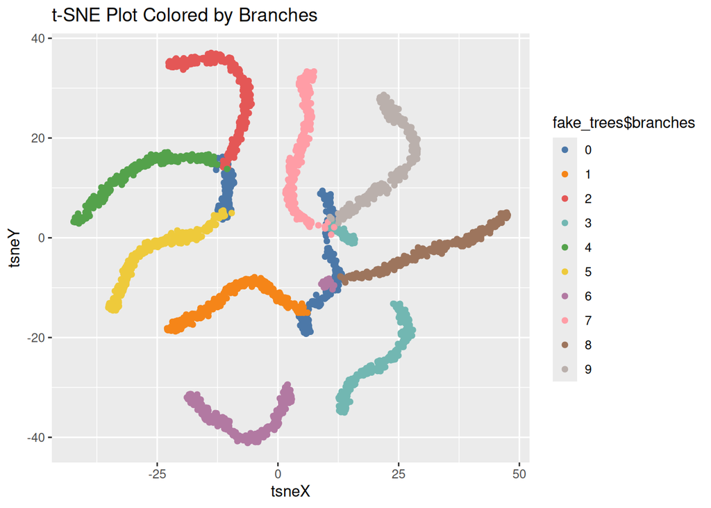

```r
ggplot(tsne_df, aes(x = tsneX, y = tsneY, color = fake_trees$branches)) +
  geom_point() +
  scale_color_manual(values = limn_pal_tableau10()) +
  ggtitle("t-SNE Plot Colored by Branches")
```

## Step 6: Linked t-SNE and Grand Tour

Below is a snapshot of the linked brushing interface:

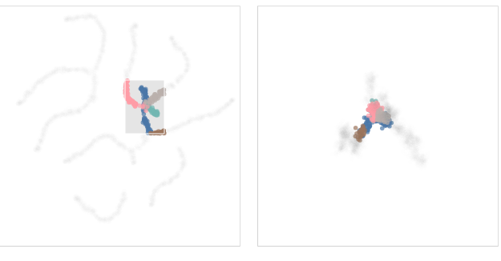

Linked Brushing Example

### Understanding Linked Brushing

Linked brushing refers to the ability to select points in one plot (like the t-SNE view) and see the corresponding points highlighted in the other (grand tour) view. In the image above: - The **left panel** shows the interactive t-SNE plot. - The **right panel** displays the dynamic grand tour view. - By selecting a region on the left, the corresponding points in the right view are highlighted, allowing us to understand how the NLDR method (t-SNE) relates to the original high-dimensional structure.

This interactivity is crucial for diagnosing possible distortions introduced by NLDR methods, helping analysts validate and interpret cluster structures accurately. Using `limn_tour_link` to create a linked tour:

```r
limn_tour_link(embed_data = tsne_df,
               tour_data = fake_trees,
               cols = PC1:PC10,
               color = branches)
```

## Step 7: Storing the Result

Optionally, we can store the result of the linked tour:

```r
res <- limn_tour_link(embed_data = tsne_df,
                      tour_data = fake_trees,
                      cols = PC1:PC10,
                      color = branches)
```

## Conclusion

This solution demonstrates how to use the Liminal package to explore high-dimensional data interactively, comparing t-SNE embeddings with a linked grand tour. Linked brushing helps us understand discrepancies and potential artifacts in the t-SNE visualization.